# Project #2: Analysis of Restaurant Transactions on Sales

### Shobha’s visualizations:

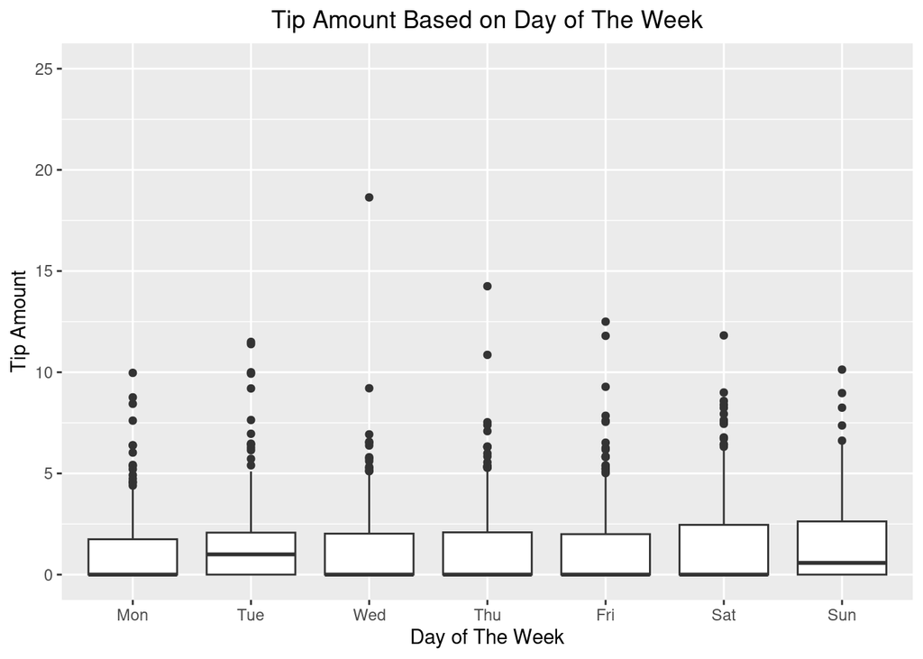

```r
# Visualization 1: This plot shows the relationship between distribution based and Day
ggplot(Tenoch_Transactions, aes(x = Day, y = Tip)) +
  geom_boxplot() +
  ylim(0, 25) +
  labs(x = "Day of The Week", y = "Tip Amount") +
  ggtitle("Tip Amount Based on Day of The Week") +
  theme(plot.title = element_text(hjust = 0.5))
```

```r
#Create new dataset without O values for tip
Tenoch_Transactions_0 <- Tenoch_Transactions %>%
  filter(Tip != 0)
```

This box plot represents the tip amount on different days of the week. Tuesday has the highest median and Sunday has the second highest. However, the medians of the other days of the week are all 0. This somewhat skews the results, so the 0’s could be removed to give a more accurate visualization of the distribution of existing tip values for those days.

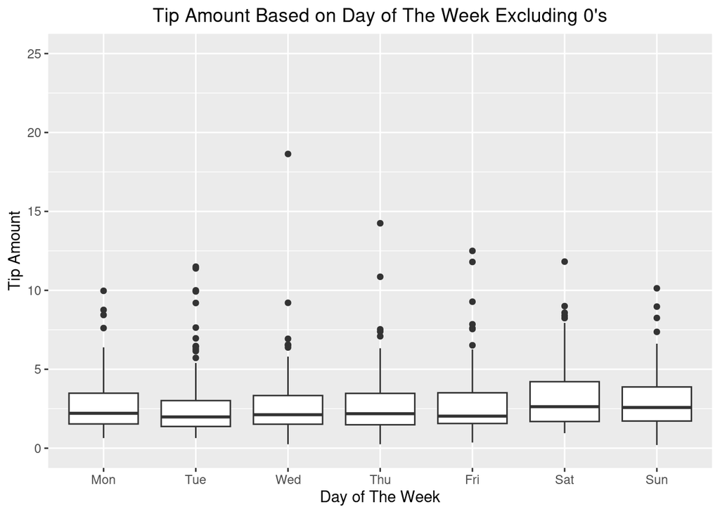

```r
# Visualization 2: This plot shows the relationship between tip distribution based on day excluding tip amounts of 0
ggplot(Tenoch_Transactions_0, aes(x = Day, y = Tip)) +
  geom_boxplot() +
  ylim(0, 25) +
  labs(x = "Day of The Week", y = "Tip Amount") +
  ggtitle("Tip Amount Based on Day of The Week Excluding 0's") +
  theme(plot.title = element_text(hjust = 0.5))
```

This box plot represents the tip amount on different days of the week excluding tip amounts of $0. There isn’t a huge amount of variation between the different days of the week, but Saturday has the highest median tip amount, closely followed by Sunday and Monday. Since Saturday and Sunday seem to have the highest median tip amounts, it can be concluded that the median tip amount is higher on weekends than it is on weekdays.